# CNN on the CIFAR100 Data

Biostat 274

Author

Dr. Jin Zhou @ UCLA

Published

February 18, 2026

Display system information for reproducibility.

**Python**

```python
import IPython
print(IPython.sys_info())
```

```
{'commit_hash': '5ed988a91',
 'commit_source': 'installation',
 'default_encoding': 'utf-8',
 'ipython_path': '/Users/jinjinzhou/.virtualenvs/r-tensorflow/lib/python3.10/site-packages/IPython',
 'ipython_version': '8.33.0',
 'os_name': 'posix',
 'platform': 'macOS-15.7.3-arm64-arm-64bit',
 'sys_executable': '/Users/jinjinzhou/.virtualenvs/r-tensorflow/bin/python',
 'sys_platform': 'darwin',
 'sys_version': '3.10.16 (main, Mar  3 2025, 20:01:33) [Clang 16.0.0 '
                '(clang-1600.0.26.6)]'}
```

**R**

```r
#| label: setup
#| include: false
library(reticulate)
use_python("/Users/jinjinzhou/.virtualenvs/r-tensorflow/bin/python", required = TRUE)
py_config()
```

```
python:         /Users/jinjinzhou/.virtualenvs/r-tensorflow/bin/python
libpython:      /Users/jinjinzhou/.pyenv/versions/3.10.16/lib/libpython3.10.dylib
pythonhome:     /Users/jinjinzhou/.virtualenvs/r-tensorflow:/Users/jinjinzhou/.virtualenvs/r-tensorflow
version:        3.10.16 (main, Mar  3 2025, 20:01:33) [Clang 16.0.0 (clang-1600.0.26.6)]
numpy:          /Users/jinjinzhou/.virtualenvs/r-tensorflow/lib/python3.10/site-packages/numpy
numpy_version:  2.0.2

NOTE: Python version was forced by RETICULATE_PYTHON
```

Load some libraries.

**Python**

```python
# Load the pandas library
import pandas as pd
# Load numpy for array manipulation
import numpy as np
# Load seaborn plotting library
import seaborn as sns
import matplotlib.pyplot as plt

# Set font sizes in plots
sns.set(font_scale = 1.2)
# Display all columns
pd.set_option('display.max_columns', None)

# Load Tensorflow and Keras
import tensorflow as tf
from tensorflow import keras
from tensorflow.keras import layers
```

**R**

```r
library(keras3)
library(jpeg)
```

- The **CIFAR100** database is a large database of $32 \times 32$ color images that is commonly used for training and testing machine learning algorithms.
- 50,000 training images, 10,000 testing images.

## 1 Prepare data

Acquire data:

**Python**

```python
# Load the data and split it between train and test sets
(x_train, y_train), (x_test, y_test) = keras.datasets.cifar100.load_data()
# Training set
x_train.shape
```

```
(50000, 32, 32, 3)
```

```python
y_train.shape
```

```
(50000, 1)
```

```python
# Test set
x_test.shape
```

```
(10000, 32, 32, 3)
```

```python
y_test.shape
```

```
(10000, 1)
```

**R**

```r
cifar100 <- dataset_cifar100()
x_train <- cifar100$train$x
y_train <- cifar100$train$y
x_test <- cifar100$test$x
y_test <- cifar100$test$y
```

Training set:

```r
dim(x_train)
```

```
[1] 50000    32    32     3
```

```r
dim(y_train)
```

```
[1] 50000     1
```

Testing set:

```r
dim(y_train)
```

```
[1] 50000     1
```

```r
dim(y_test)
```

```
[1] 10000     1
```

For CNN, we keep the $32 \times 32 \times 3$ tensor structure, instead of vectorizing into a long vector.

**Python**

```python
# Rescale
x_train = x_train / 255
x_test = x_test / 255
# Train
x_train.shape
```

```
(50000, 32, 32, 3)
```

```python
# Test
x_test.shape
```

```
(10000, 32, 32, 3)
```

**R**

```r
# rescale
x_train <- x_train / 255
x_test <- x_test / 255
dim(x_train)
```

```
[1] 50000    32    32     3
```

```r
dim(x_test)
```

```
[1] 10000    32    32     3
```

Encode $y$ as binary class matrix:

**Python**

```python
y_train = keras.utils.to_categorical(y_train, 100)
y_test = keras.utils.to_categorical(y_test, 100)
# Train
y_train.shape
```

```
(50000, 100)
```

```python
# Test
y_test.shape
```

```
(10000, 100)
```

```python
# First train instance
y_train[0]
```

```
array([0., 0., 0., 0., 0., 0., 0., 0., 0., 0., 0., 0., 0., 0., 0., 0., 0.,
       0., 0., 1., 0., 0., 0., 0., 0., 0., 0., 0., 0., 0., 0., 0., 0., 0.,
       0., 0., 0., 0., 0., 0., 0., 0., 0., 0., 0., 0., 0., 0., 0., 0., 0.,
       0., 0., 0., 0., 0., 0., 0., 0., 0., 0., 0., 0., 0., 0., 0., 0., 0.,
       0., 0., 0., 0., 0., 0., 0., 0., 0., 0., 0., 0., 0., 0., 0., 0., 0.,
       0., 0., 0., 0., 0., 0., 0., 0., 0., 0., 0., 0., 0., 0., 0.])
```

**R**

```r
y_train <- to_categorical(y_train, 100)
y_test <- to_categorical(y_test, 100)
dim(y_train)
```

```
[1] 50000   100
```

```r
dim(y_test)
```

```
[1] 10000   100
```

```r
# head(y_train)
```

Show a few images:

**Python**

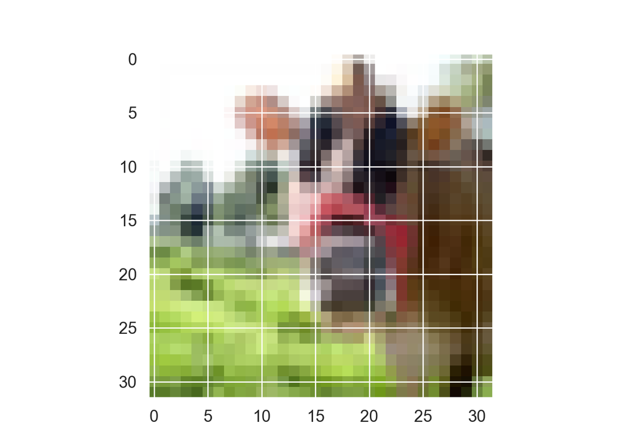

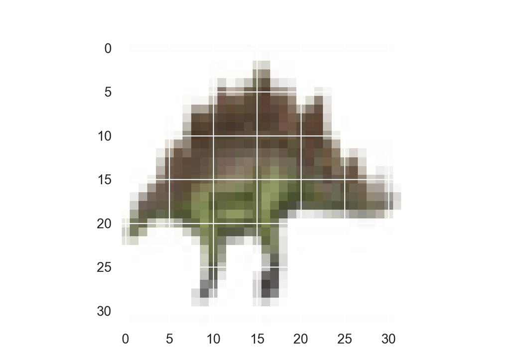

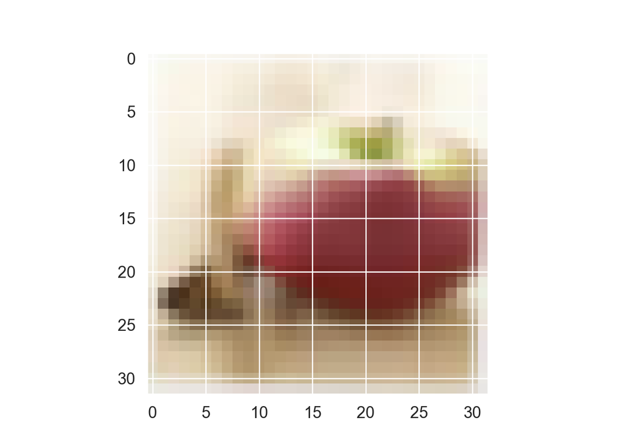

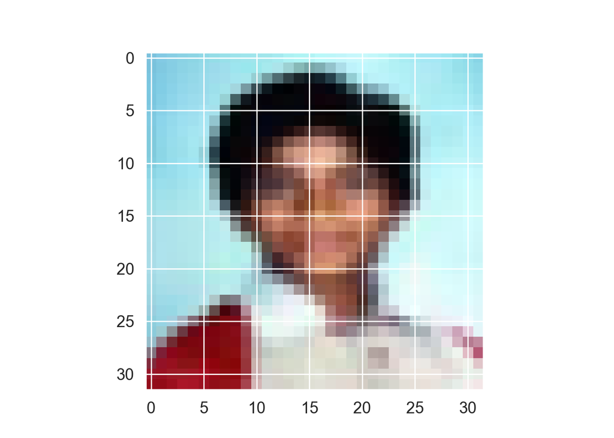

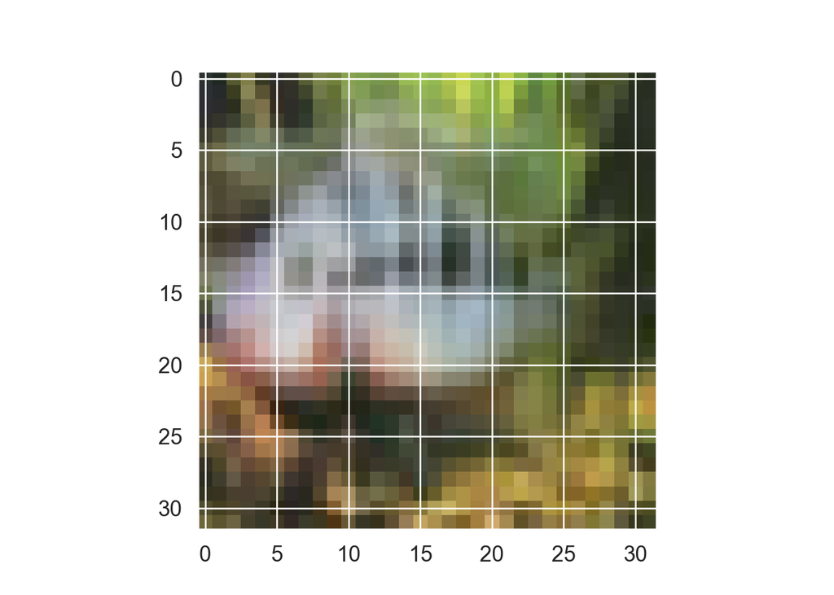

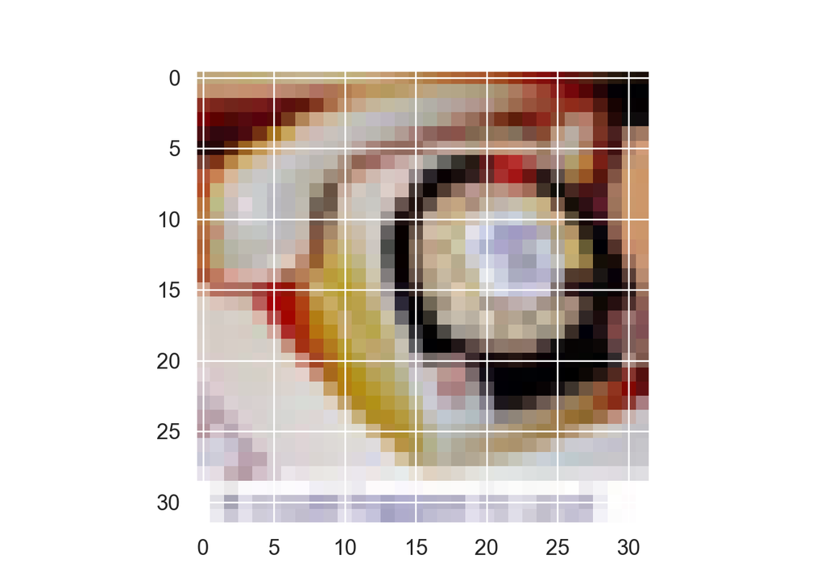

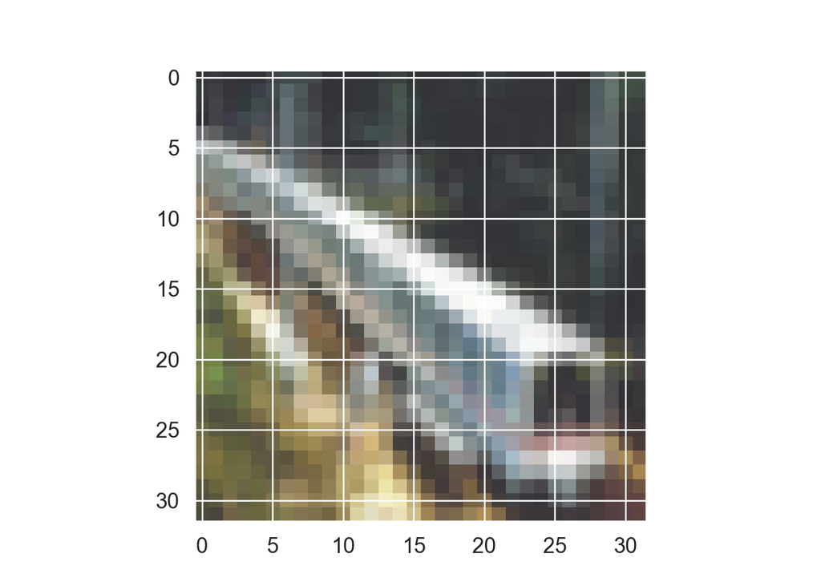

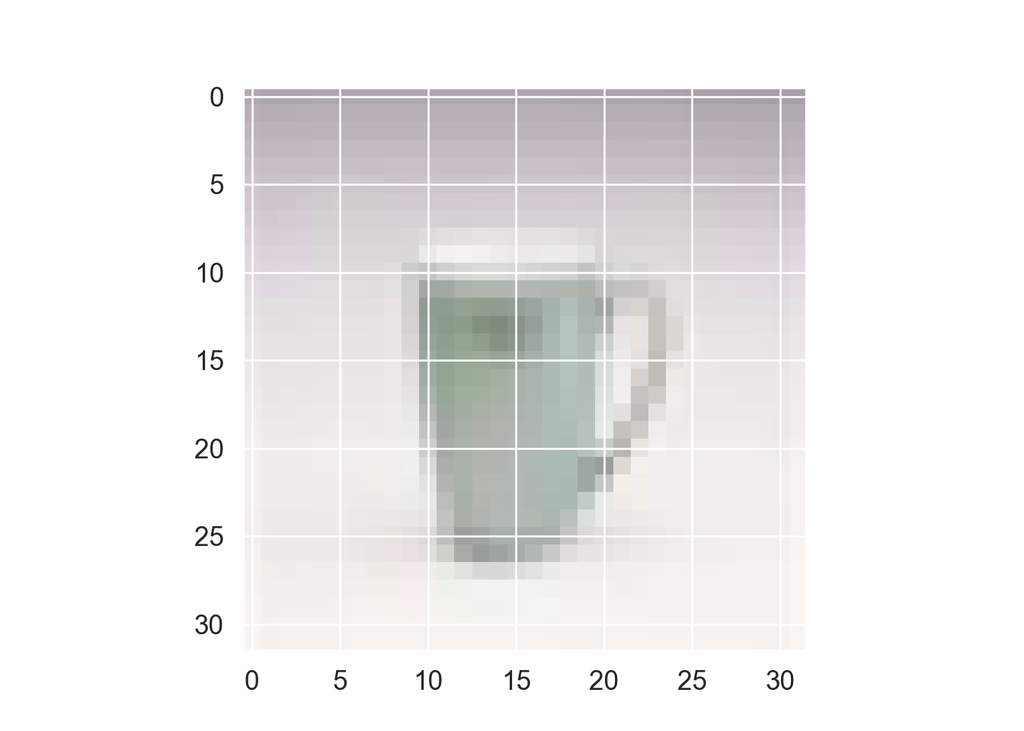

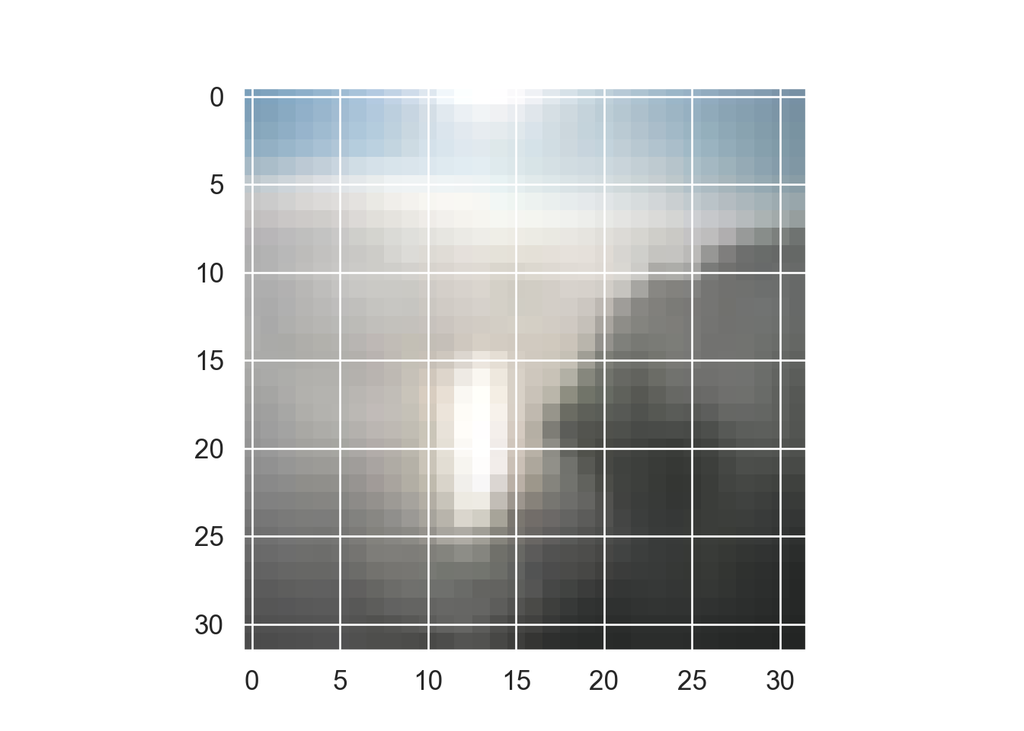

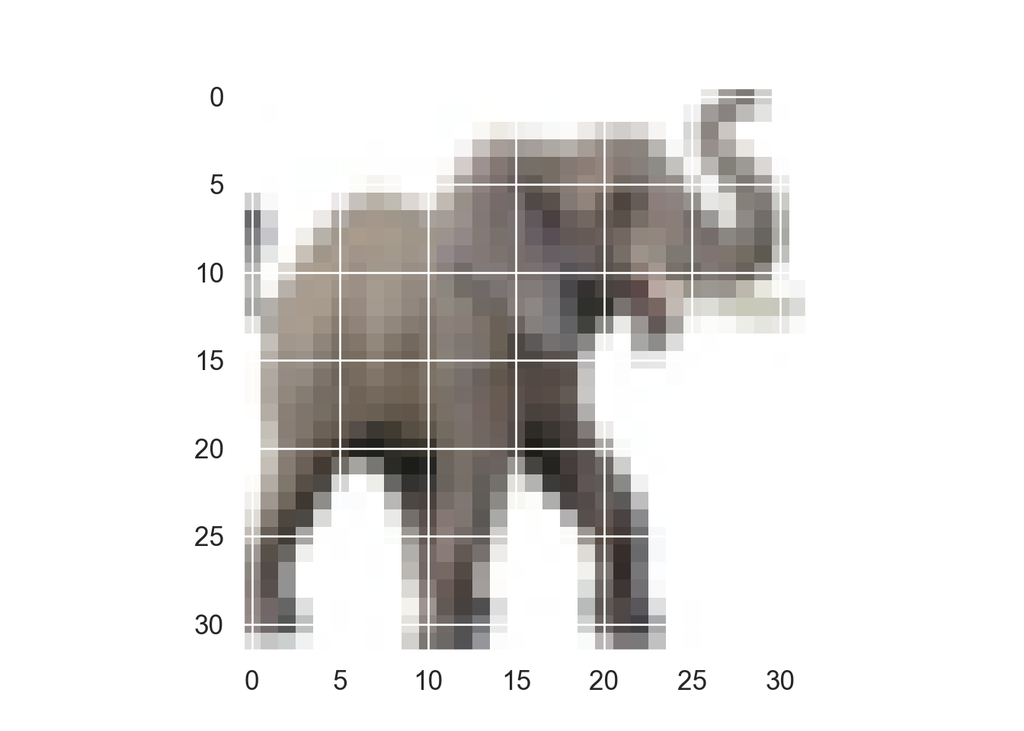

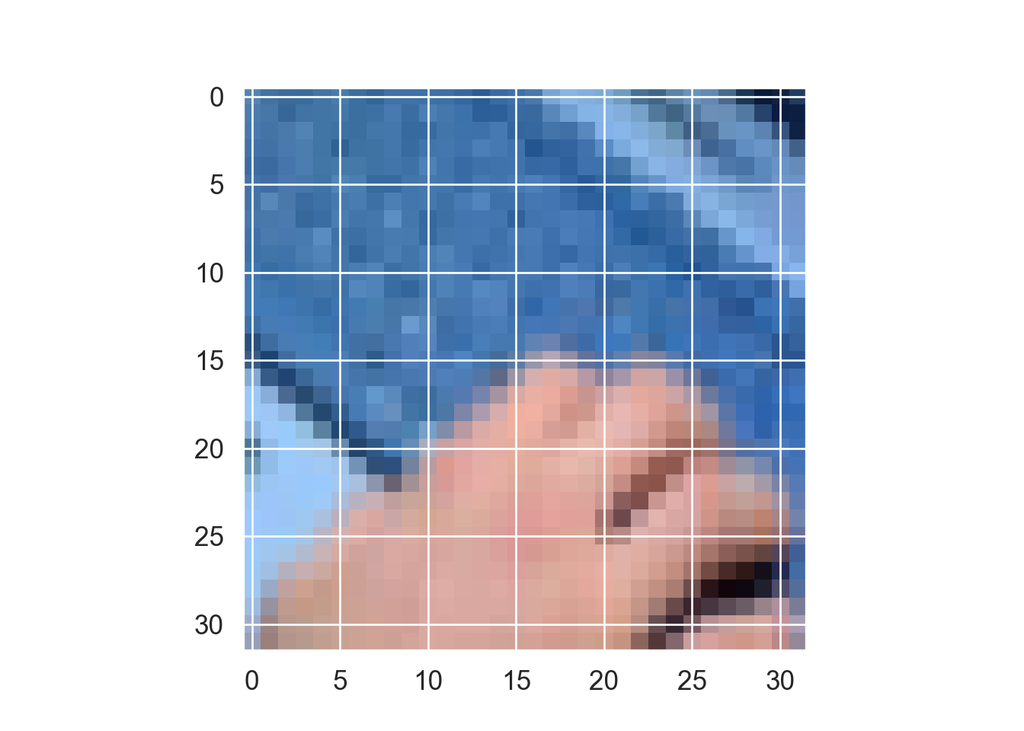

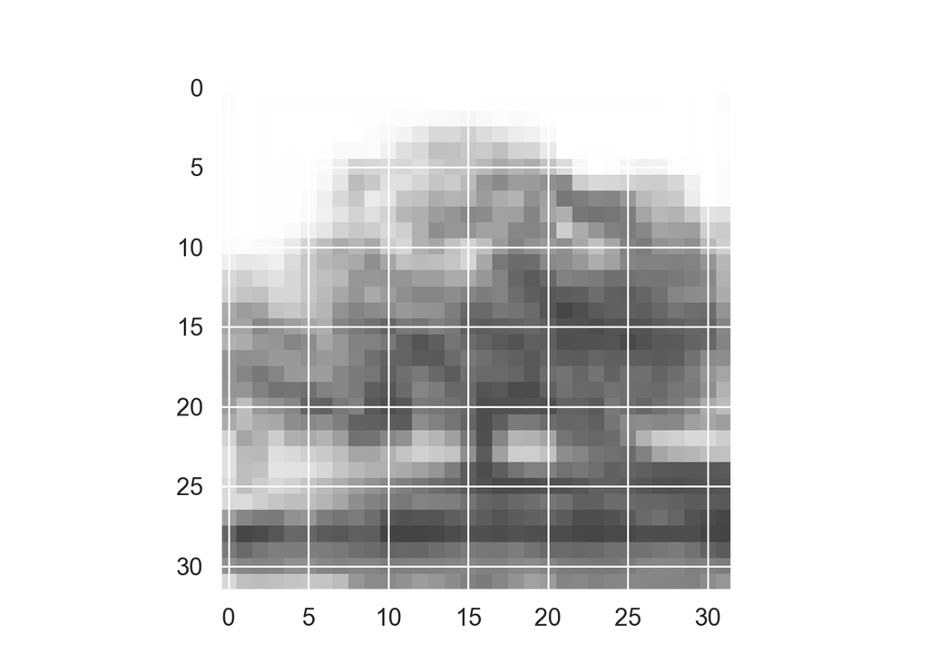

[13 more figures not shown]

```python
import matplotlib.pyplot as plt

# Feature: 32x32 color image
for i in range(25):
  plt.figure()
  plt.imshow(x_train[i]);
  plt.show()
```

**R**

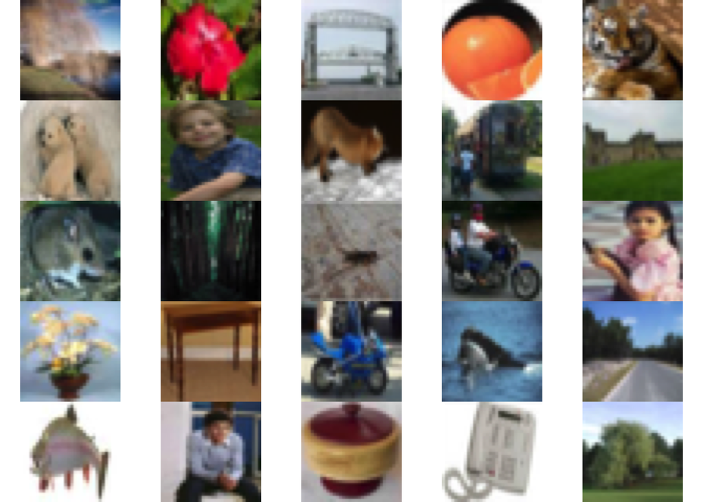

```r
par(mar = c(0, 0, 0, 0), mfrow = c(5, 5))
index <- sample(seq(50000), 25)
for (i in index) plot(as.raster(x_train[i,,, ]))
```

## 2 Define the model

**Python**

```python
model = keras.Sequential(
  [
    keras.Input(shape = (32, 32, 3)),
    layers.Conv2D(
      filters = 32,
      kernel_size = (3, 3),
      padding = 'same',
      activation = 'relu',
      # input_shape = (32, 32, 3)
      ),
    layers.MaxPooling2D(pool_size = (2, 2)),
    layers.Conv2D(
      filters = 64,
      kernel_size = (3, 3),
      padding = 'same',
      activation = 'relu'
      ),
    layers.MaxPooling2D(pool_size = (2, 2)),
    layers.Conv2D(
      filters = 128,
      kernel_size = (3, 3),
      padding = 'same',
      activation = 'relu'
      ),
    layers.MaxPooling2D(pool_size = (2, 2)),
    layers.Conv2D(
      filters = 256,
      kernel_size = (3, 3),
      padding = 'same',
      activation = 'relu'
      ),
    layers.MaxPooling2D(pool_size = (2, 2)),
    layers.Flatten(),
    layers.Dropout(rate = 0.5),
    layers.Dense(units = 512, activation = 'relu'),
    layers.Dense(units = 100, activation = 'softmax')
]
)

model.summary()
```

```
Model: "sequential"
┏━━━━━━━━━━━━━━━━━━━━━━━━━━━━━━━━━┳━━━━━━━━━━━━━━━━━━━━━━━━┳━━━━━━━━━━━━━━━┓
┃ Layer (type)                    ┃ Output Shape           ┃       Param # ┃
┡━━━━━━━━━━━━━━━━━━━━━━━━━━━━━━━━━╇━━━━━━━━━━━━━━━━━━━━━━━━╇━━━━━━━━━━━━━━━┩
│ conv2d (Conv2D)                 │ (None, 32, 32, 32)     │           896 │
├─────────────────────────────────┼────────────────────────┼───────────────┤
│ max_pooling2d (MaxPooling2D)    │ (None, 16, 16, 32)     │             0 │
├─────────────────────────────────┼────────────────────────┼───────────────┤
│ conv2d_1 (Conv2D)               │ (None, 16, 16, 64)     │        18,496 │
├─────────────────────────────────┼────────────────────────┼───────────────┤
│ max_pooling2d_1 (MaxPooling2D)  │ (None, 8, 8, 64)       │             0 │
├─────────────────────────────────┼────────────────────────┼───────────────┤
│ conv2d_2 (Conv2D)               │ (None, 8, 8, 128)      │        73,856 │
├─────────────────────────────────┼────────────────────────┼───────────────┤
│ max_pooling2d_2 (MaxPooling2D)  │ (None, 4, 4, 128)      │             0 │
├─────────────────────────────────┼────────────────────────┼───────────────┤
│ conv2d_3 (Conv2D)               │ (None, 4, 4, 256)      │       295,168 │
├─────────────────────────────────┼────────────────────────┼───────────────┤
│ max_pooling2d_3 (MaxPooling2D)  │ (None, 2, 2, 256)      │             0 │
├─────────────────────────────────┼────────────────────────┼───────────────┤
│ flatten (Flatten)               │ (None, 1024)           │             0 │
├─────────────────────────────────┼────────────────────────┼───────────────┤
│ dropout (Dropout)               │ (None, 1024)           │             0 │
├─────────────────────────────────┼────────────────────────┼───────────────┤
│ dense (Dense)                   │ (None, 512)            │       524,800 │
├─────────────────────────────────┼────────────────────────┼───────────────┤
│ dense_1 (Dense)                 │ (None, 100)            │        51,300 │
└─────────────────────────────────┴────────────────────────┴───────────────┘
 Total params: 964,516 (3.68 MB)
 Trainable params: 964,516 (3.68 MB)
 Non-trainable params: 0 (0.00 B)
```

Plot the model:

```python
tf.keras.utils.plot_model(
    model,
    to_file = "model.png",
    show_shapes = True,
    show_dtype = False,
    show_layer_names = True,
    rankdir = "TB",
    expand_nested = False,
    dpi = 96,
    layer_range = None,
    show_layer_activations = False,
)
```

```
You must install pydot (`pip install pydot`) for `plot_model` to work.
```

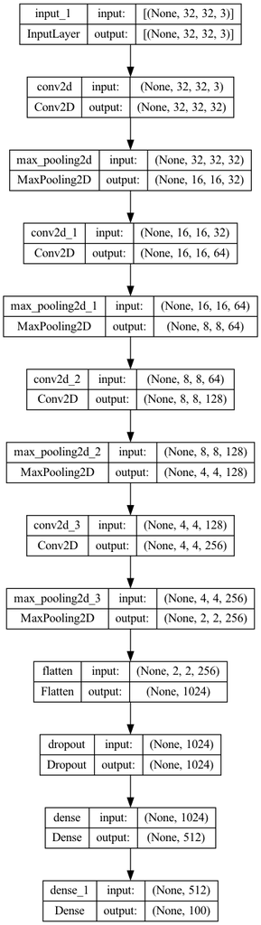

**R**

```r
model <- keras_model_sequential()  %>%
  layer_conv_2d(
    filters = 32,
    kernel_size = c(3, 3),
    padding = "same",
    activation = "relu",
    input_shape = c(32, 32, 3)
    ) %>%
  layer_max_pooling_2d(pool_size = c(2, 2)) %>%
  layer_conv_2d(
    filters = 64,
    kernel_size = c(3, 3),
    padding = "same",
    activation = "relu"
    ) %>%
  layer_max_pooling_2d(pool_size = c(2, 2)) %>%
  layer_conv_2d(
    filters = 128,
    kernel_size = c(3, 3),
    padding = "same",
    activation = "relu"
    ) %>%
  layer_max_pooling_2d(pool_size = c(2, 2)) %>%
  layer_conv_2d(
    filters = 256,
    kernel_size = c(3, 3),
    padding = "same",
    activation = "relu"
    ) %>%
  layer_max_pooling_2d(pool_size = c(2, 2)) %>%
  layer_flatten() %>%
  layer_dropout(rate = 0.5) %>%
  layer_dense(units = 512, activation = "relu") %>%
  layer_dense(units = 100, activation = "softmax")

summary(model)
```

```
Model: "sequential_1"
┏━━━━━━━━━━━━━━━━━━━━━━━━━━━━━━━━━━━┳━━━━━━━━━━━━━━━━━━━━━━━━━━┳━━━━━━━━━━━━━━━┓
┃ Layer (type)                      ┃ Output Shape             ┃       Param # ┃
┡━━━━━━━━━━━━━━━━━━━━━━━━━━━━━━━━━━━╇━━━━━━━━━━━━━━━━━━━━━━━━━━╇━━━━━━━━━━━━━━━┩
│ conv2d_4 (Conv2D)                 │ (None, 32, 32, 32)       │           896 │
├───────────────────────────────────┼──────────────────────────┼───────────────┤
│ max_pooling2d_4 (MaxPooling2D)    │ (None, 16, 16, 32)       │             0 │
├───────────────────────────────────┼──────────────────────────┼───────────────┤
│ conv2d_5 (Conv2D)                 │ (None, 16, 16, 64)       │        18,496 │
├───────────────────────────────────┼──────────────────────────┼───────────────┤
│ max_pooling2d_5 (MaxPooling2D)    │ (None, 8, 8, 64)         │             0 │
├───────────────────────────────────┼──────────────────────────┼───────────────┤
│ conv2d_6 (Conv2D)                 │ (None, 8, 8, 128)        │        73,856 │
├───────────────────────────────────┼──────────────────────────┼───────────────┤
│ max_pooling2d_6 (MaxPooling2D)    │ (None, 4, 4, 128)        │             0 │
├───────────────────────────────────┼──────────────────────────┼───────────────┤
│ conv2d_7 (Conv2D)                 │ (None, 4, 4, 256)        │       295,168 │
├───────────────────────────────────┼──────────────────────────┼───────────────┤
│ max_pooling2d_7 (MaxPooling2D)    │ (None, 2, 2, 256)        │             0 │
├───────────────────────────────────┼──────────────────────────┼───────────────┤
│ flatten_1 (Flatten)               │ (None, 1024)             │             0 │
├───────────────────────────────────┼──────────────────────────┼───────────────┤
│ dropout_1 (Dropout)               │ (None, 1024)             │             0 │
├───────────────────────────────────┼──────────────────────────┼───────────────┤
│ dense_2 (Dense)                   │ (None, 512)              │       524,800 │
├───────────────────────────────────┼──────────────────────────┼───────────────┤
│ dense_3 (Dense)                   │ (None, 100)              │        51,300 │
└───────────────────────────────────┴──────────────────────────┴───────────────┘
 Total params: 964,516 (3.68 MB)
 Trainable params: 964,516 (3.68 MB)
 Non-trainable params: 0 (0.00 B)
```

Compile the model with appropriate loss function, optimizer, and metrics:

**Python**

```python
model.compile(
  loss = "categorical_crossentropy",
  optimizer = "rmsprop",
  metrics = ["accuracy"]
)
```

**R**

```r
model %>% compile(
  loss = 'categorical_crossentropy',
  optimizer = optimizer_rmsprop(),
  metrics = c('accuracy')
)
```

## 3 Training and validation

**Python**

```python
batch_size = 128
epochs = 30

history = model.fit(
  x_train,
  y_train,
  batch_size = batch_size,
  epochs = epochs,
  validation_split = 0.2
)
```

Plot training history:

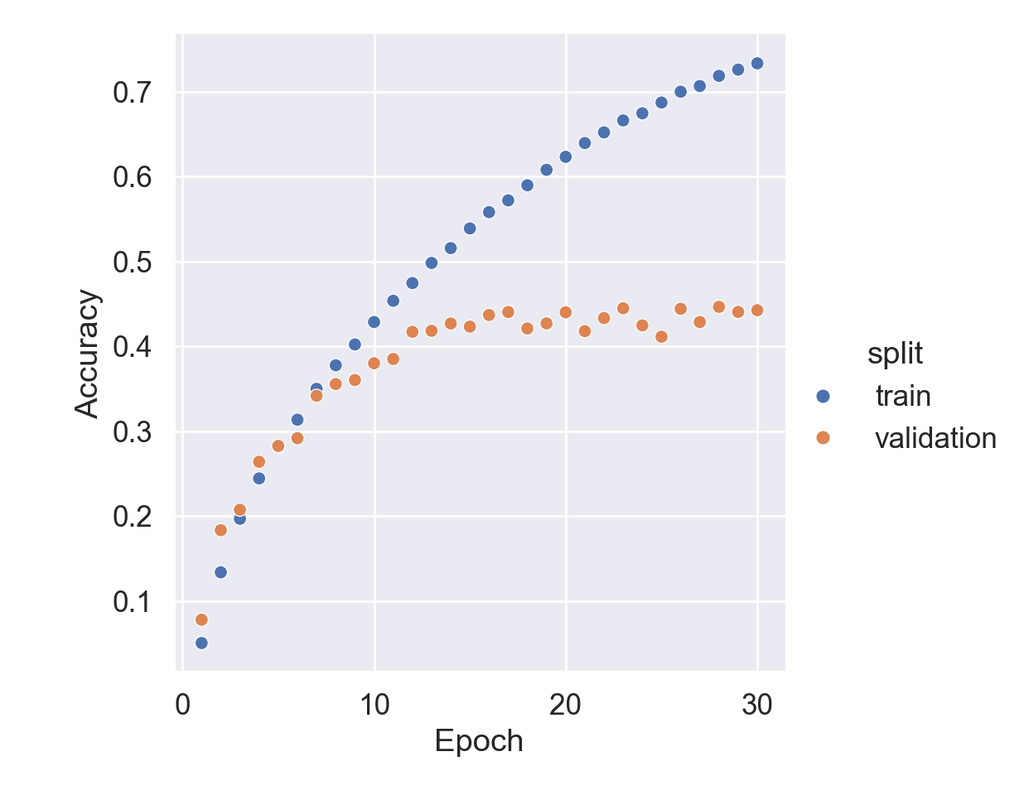

```python
hist = pd.DataFrame(history.history)
hist['epoch'] = np.arange(1, epochs + 1)
hist = hist.melt(
  id_vars = ['epoch'],
  value_vars = ['loss', 'accuracy', 'val_loss', 'val_accuracy'],
  var_name = 'type',
  value_name = 'value'
)
hist['split'] = np.where(['val' in s for s in hist['type']], 'validation', 'train')
hist['metric'] = np.where(['loss' in s for s in hist['type']], 'loss', 'accuracy')

# Accuracy trace plot
plt.figure()
sns.relplot(
  data = hist[hist['metric'] == 'accuracy'],
  kind = 'scatter',
  x = 'epoch',
  y = 'value',
  hue = 'split'
).set(
  xlabel = 'Epoch',
  ylabel = 'Accuracy'
);
plt.show()
```

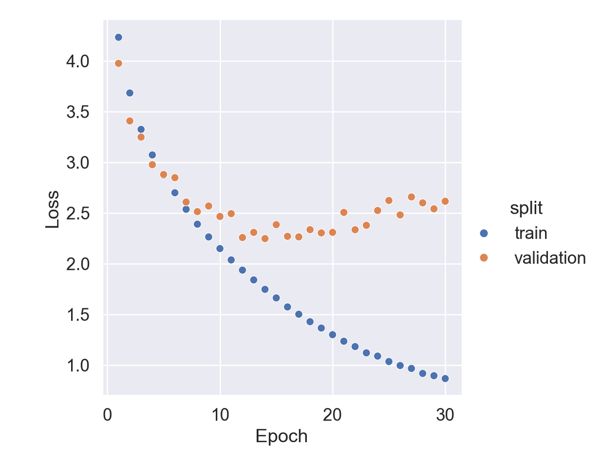

```python
# Loss trace plot
plt.figure()
sns.relplot(
  data = hist[hist['metric'] == 'loss'],
  kind = 'scatter',
  x = 'epoch',
  y = 'value',
  hue = 'split'
).set(
  xlabel = 'Epoch',
  ylabel = 'Loss'
);
plt.show()
```

**R**

```r
system.time({
history <- model %>% fit(
  x_train, y_train,
  epochs = 30, batch_size = 128,
  validation_split = 0.2
)
})
```

```
313/313 - 14s - 43ms/step - accuracy: 0.0492 - loss: 4.2438 - val_accuracy: 0.0820 - val_loss: 4.0166
313/313 - 13s - 42ms/step - accuracy: 0.1406 - loss: 3.6498 - val_accuracy: 0.1757 - val_loss: 3.4865
313/313 - 13s - 42ms/step - accuracy: 0.2036 - loss: 3.2863 - val_accuracy: 0.2141 - val_loss: 3.1913
313/313 - 13s - 43ms/step - accuracy: 0.2487 - loss: 3.0377 - val_accuracy: 0.2662 - val_loss: 2.9640
313/313 - 14s - 43ms/step - accuracy: 0.2927 - loss: 2.8287 - val_accuracy: 0.2963 - val_loss: 2.8493
313/313 - 13s - 42ms/step - accuracy: 0.3264 - loss: 2.6509 - val_accuracy: 0.3302 - val_loss: 2.6688
313/313 - 13s - 41ms/step - accuracy: 0.3565 - loss: 2.5044 - val_accuracy: 0.3485 - val_loss: 2.5578
313/313 - 13s - 41ms/step - accuracy: 0.3889 - loss: 2.3518 - val_accuracy: 0.3518 - val_loss: 2.5584
313/313 - 13s - 42ms/step - accuracy: 0.4116 - loss: 2.2313 - val_accuracy: 0.3773 - val_loss: 2.4618
313/313 - 13s - 42ms/step - accuracy: 0.4377 - loss: 2.1101 - val_accuracy: 0.3880 - val_loss: 2.4460
313/313 - 13s - 43ms/step - accuracy: 0.4617 - loss: 2.0016 - val_accuracy: 0.3871 - val_loss: 2.4390
313/313 - 13s - 42ms/step - accuracy: 0.4817 - loss: 1.9023 - val_accuracy: 0.4127 - val_loss: 2.2944
313/313 - 13s - 43ms/step - accuracy: 0.5041 - loss: 1.8098 - val_accuracy: 0.4187 - val_loss: 2.2497
313/313 - 13s - 42ms/step - accuracy: 0.5281 - loss: 1.7132 - val_accuracy: 0.4248 - val_loss: 2.2688
313/313 - 13s - 42ms/step - accuracy: 0.5464 - loss: 1.6308 - val_accuracy: 0.4074 - val_loss: 2.3865
313/313 - 13s - 42ms/step - accuracy: 0.5622 - loss: 1.5534 - val_accuracy: 0.4258 - val_loss: 2.2961
313/313 - 13s - 42ms/step - accuracy: 0.5832 - loss: 1.4683 - val_accuracy: 0.4129 - val_loss: 2.4259
313/313 - 13s - 41ms/step - accuracy: 0.5990 - loss: 1.4020 - val_accuracy: 0.4405 - val_loss: 2.2622
313/313 - 13s - 42ms/step - accuracy: 0.6148 - loss: 1.3325 - val_accuracy: 0.4357 - val_loss: 2.2939
313/313 - 13s - 42ms/step - accuracy: 0.6305 - loss: 1.2661 - val_accuracy: 0.4361 - val_loss: 2.3386
313/313 - 13s - 42ms/step - accuracy: 0.6435 - loss: 1.2145 - val_accuracy: 0.4366 - val_loss: 2.3215
313/313 - 13s - 41ms/step - accuracy: 0.6532 - loss: 1.1630 - val_accuracy: 0.4383 - val_loss: 2.3931
313/313 - 13s - 42ms/step - accuracy: 0.6680 - loss: 1.1130 - val_accuracy: 0.4301 - val_loss: 2.4941
313/313 - 13s - 42ms/step - accuracy: 0.6855 - loss: 1.0575 - val_accuracy: 0.4402 - val_loss: 2.4656
313/313 - 13s - 42ms/step - accuracy: 0.6962 - loss: 1.0176 - val_accuracy: 0.4435 - val_loss: 2.4457
313/313 - 14s - 44ms/step - accuracy: 0.7046 - loss: 0.9752 - val_accuracy: 0.4497 - val_loss: 2.3973
313/313 - 13s - 42ms/step - accuracy: 0.7136 - loss: 0.9449 - val_accuracy: 0.4373 - val_loss: 2.5121
313/313 - 13s - 42ms/step - accuracy: 0.7246 - loss: 0.9036 - val_accuracy: 0.4344 - val_loss: 2.5615
313/313 - 13s - 42ms/step - accuracy: 0.7309 - loss: 0.8857 - val_accuracy: 0.4329 - val_loss: 2.6866
313/313 - 13s - 42ms/step - accuracy: 0.7417 - loss: 0.8473 - val_accuracy: 0.4461 - val_loss: 2.6396
```

```
    user   system  elapsed
2821.867  439.711  396.049
```

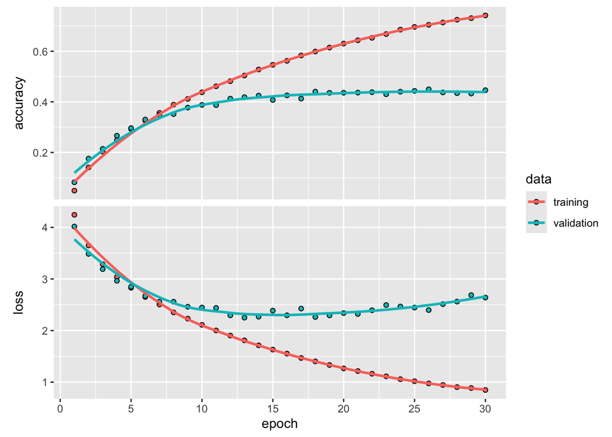

```r
plot(history)
```

## 4 Testing

Evaluate model performance on the test data:

**Python**

```python
score = model.evaluate(x_test, y_test, verbose = 0)
print("Test loss:", score[0])
```

```
Test loss: 2.5475611686706543
```

```python
print("Test accuracy:", score[1])
```

```
Test accuracy: 0.45329999923706055
```

**R**

```r
model %>% evaluate(x_test, y_test)
```

```
313/313 - 2s - 6ms/step - accuracy: 0.4537 - loss: 2.5654
```

```
$accuracy
[1] 0.4537

$loss
[1] 2.565438
```

Generate predictions on new data:

```r
predictions <- model %>% predict(x_test)
```

```
313/313 - 2s - 7ms/step
```

```r
head(predictions)
```

```
             [,1]         [,2]         [,3]         [,4]         [,5]
[1,] 1.291396e-10 2.647795e-08 2.631356e-05 3.031284e-05 3.340895e-04
[2,] 8.235011e-09 1.339871e-06 1.540561e-04 9.528415e-05 2.775955e-04
[3,] 7.355953e-11 1.757577e-07 1.090125e-04 9.006166e-05 3.489851e-03
[4,] 3.534460e-02 3.397846e-05 2.018928e-02 1.097459e-02 2.776452e-02
[5,] 4.573429e-14 5.638329e-13 7.954059e-18 2.613952e-17 1.166285e-14
[6,] 2.271213e-08 2.836129e-08 7.031601e-08 5.912840e-04 2.152192e-04
             [,6]         [,7]         [,8]         [,9]        [,10]
[1,] 2.215048e-04 3.373082e-08 1.061546e-07 7.646040e-05 2.908492e-06
[2,] 4.962792e-06 6.639455e-06 5.680717e-06 6.026832e-04 1.728265e-04
[3,] 4.527494e-06 4.185797e-05 6.555504e-06 1.876850e-07 7.017321e-07
[4,] 4.249937e-05 1.969142e-05 4.127843e-07 1.047804e-05 2.011914e-04
[5,] 3.732477e-09 4.705402e-18 5.340981e-17 7.017665e-18 6.566068e-15
[6,] 1.997895e-09 5.018782e-01 9.113103e-03 2.896995e-06 1.100109e-05
            [,11]        [,12]        [,13]        [,14]        [,15]
```

[output cut: 125 more lines]